# IODS course project

## Simple regression

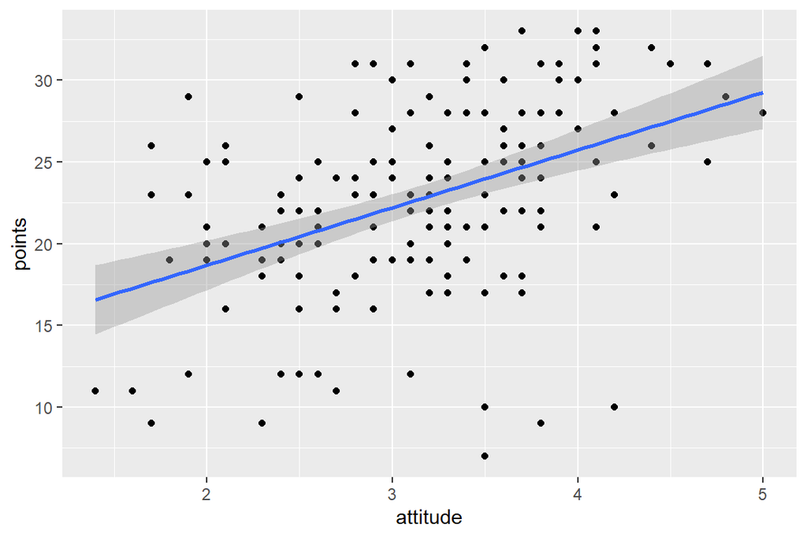

```r
# a scatter plot of points versus attitude
library(ggplot2)
qplot(attitude, points, data = Data2) + geom_smooth(method = "lm")
```

```r
# fit a linear model
my_model <- lm(points ~ attitude, data = Data2)

# print out a summary of the model
summary(my_model)
```

```
##
## Call:
## lm(formula = points ~ attitude, data = Data2)
##
## Residuals:
##      Min       1Q   Median       3Q      Max
## -16.9763  -3.2119   0.4339   4.1534  10.6645
##
## Coefficients:
##             Estimate Std. Error t value Pr(>|t|)
## (Intercept)  11.6372     1.8303   6.358 1.95e-09 ***
## attitude      3.5255     0.5674   6.214 4.12e-09 ***
## ---
## Signif. codes:  0 '***' 0.001 '**' 0.01 '*' 0.05 '.' 0.1 ' ' 1
##
## Residual standard error: 5.32 on 164 degrees of freedom
## Multiple R-squared:  0.1906, Adjusted R-squared:  0.1856
## F-statistic: 38.61 on 1 and 164 DF,  p-value: 4.119e-09
```

**Interpretations** *The p-value suggests that there there is a significant relation between points and attitude*

## Multiple regression

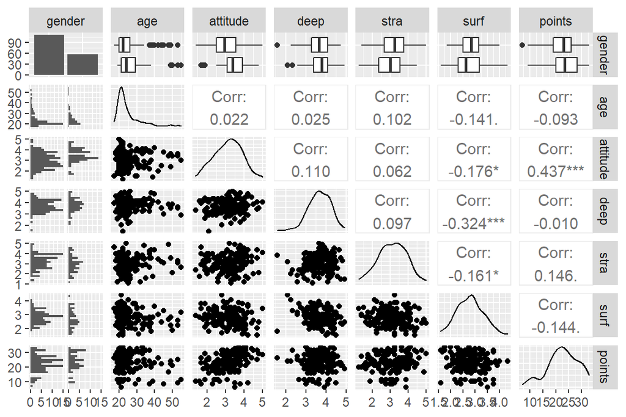

```r
library(GGally)
library(ggplot2)
# create an plot matrix with ggpairs()
ggpairs(Data2, lower = list(combo = wrap("facethist", bins = 20)))
```

```r
# create a regression model with multiple explanatory variables
my_model2 <- lm(points ~ attitude + stra, data = Data2)

# print out a summary of the model
summary(my_model2)
```

```
##
## Call:
## lm(formula = points ~ attitude + stra, data = Data2)
##
## Residuals:
##      Min       1Q   Median       3Q      Max
## -17.6436  -3.3113   0.5575   3.7928  10.9295
##
## Coefficients:
##             Estimate Std. Error t value Pr(>|t|)
## (Intercept)   8.9729     2.3959   3.745  0.00025 ***
## attitude      3.4658     0.5652   6.132 6.31e-09 ***
## stra          0.9137     0.5345   1.709  0.08927 .
## ---
## Signif. codes:  0 '***' 0.001 '**' 0.01 '*' 0.05 '.' 0.1 ' ' 1
##
## Residual standard error: 5.289 on 163 degrees of freedom
## Multiple R-squared:  0.2048, Adjusted R-squared:  0.1951
## F-statistic: 20.99 on 2 and 163 DF,  p-value: 7.734e-09
```

```r
#adding third variable as surf

my_model3 <- lm(points ~ attitude + stra + surf, data = Data2)

#printing out a summary of the model
summary(my_model3)
```

```
##
## Call:
## lm(formula = points ~ attitude + stra + surf, data = Data2)
##
## Residuals:
##      Min       1Q   Median       3Q      Max
## -17.1550  -3.4346   0.5156   3.6401  10.8952
##
## Coefficients:
##             Estimate Std. Error t value Pr(>|t|)
## (Intercept)  11.0171     3.6837   2.991  0.00322 **
## attitude      3.3952     0.5741   5.913 1.93e-08 ***
## stra          0.8531     0.5416   1.575  0.11716
## surf         -0.5861     0.8014  -0.731  0.46563
## ---
## Signif. codes:  0 '***' 0.001 '**' 0.01 '*' 0.05 '.' 0.1 ' ' 1
##
## Residual standard error: 5.296 on 162 degrees of freedom
## Multiple R-squared:  0.2074, Adjusted R-squared:  0.1927
## F-statistic: 14.13 on 3 and 162 DF,  p-value: 3.156e-08
```

**Interpretation of multiple regression** *There is a significant increase in points with 1 unit increase in attitude. With 1 unit increase in attitude there is not a significant increase in stra and surf*

##Graphical model validation

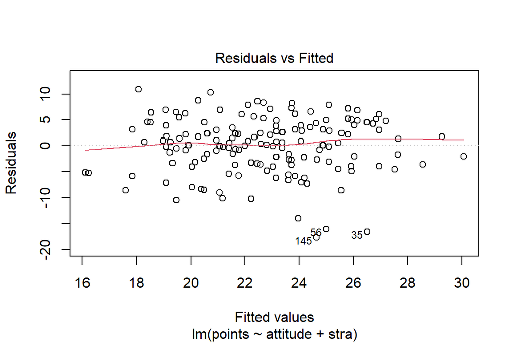

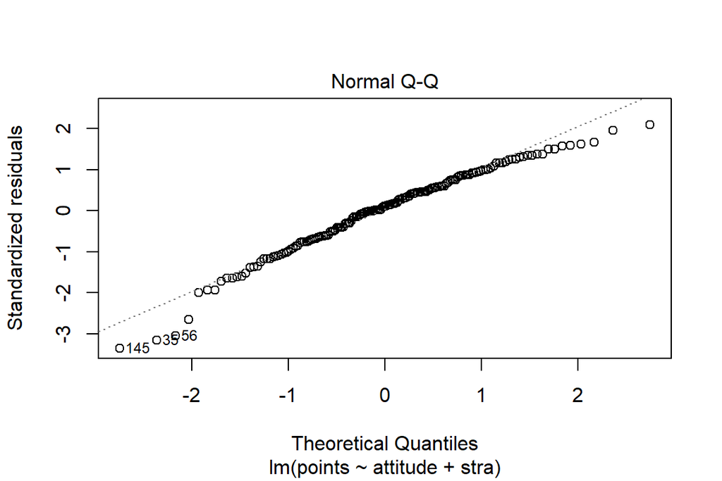

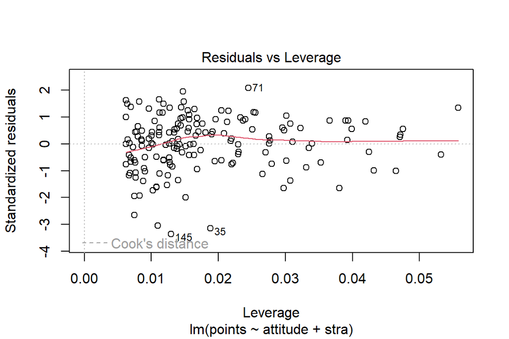

```r
# create a regression model with multiple explanatory variables
my_model2 <- lm(points ~ attitude + stra, data = Data2)

# draw diagnostic plots using the plot() function. Choose the plots 1, 2 and 5

plot(my_model2, c(1,2,5))
```

**Interpretation of residual models**

**2. Normal QQ-plot** *In the diagram below, the quantile values of the standard normal distribution are plotted on the x-axis in the Normal QQ plot, and the corresponding quantile values of the dataset are plotted on the y-axis. You can see that the points fall close to the 45-degree reference line. In the above plot we can see that although most of the observations are equally distributed and falls on the reference line but in the beginning and in the end of the plot, there are some discrepancies, especially with points 145, 35 and 56 in the beginning.*

## Making predictions

```r
# Create model object m
m <- lm(points ~ attitude, data = Data2)

# print out a summary of the model
summary(m)
```

```
##
## Call:
## lm(formula = points ~ attitude, data = Data2)
##
## Residuals:
##      Min       1Q   Median       3Q      Max
## -16.9763  -3.2119   0.4339   4.1534  10.6645
##
## Coefficients:
##             Estimate Std. Error t value Pr(>|t|)
## (Intercept)  11.6372     1.8303   6.358 1.95e-09 ***
## attitude      3.5255     0.5674   6.214 4.12e-09 ***
## ---
## Signif. codes:  0 '***' 0.001 '**' 0.01 '*' 0.05 '.' 0.1 ' ' 1
##
## Residual standard error: 5.32 on 164 degrees of freedom
## Multiple R-squared:  0.1906, Adjusted R-squared:  0.1856
## F-statistic: 38.61 on 1 and 164 DF,  p-value: 4.119e-09
```

```r
# New observations
new_attitudes <- c("Mia" = 3.8, "Mike"= 4.4, "Riikka" = 2.2, "Pekka" = 2.9)
new_data <- data.frame(attitude = new_attitudes)

# Print out the new data
summary(new_data)
```

```
##     attitude
##  Min.   :2.200
##  1st Qu.:2.725
##  Median :3.350
##  Mean   :3.325
##  3rd Qu.:3.950
##  Max.   :4.400
```

```r
# Predict the new students exam points based on attitude
predict(m, newdata = new_data)
```

```
##      Mia     Mike   Riikka    Pekka
## 25.03390 27.14918 19.39317 21.86099
```

**Interpreation** *The predict functions tells that for the new data and new students as well there is a substantial increase in one unit of attitude with increase in one unit of points.

*End of chapter*

# Chapter. Logistic regression Analysis

```r
date()
```

```
## [1] "Fri Nov 25 15:00:41 2022"
```

**About the Data set**

*The data was collected for the following paper:* *P. Cortez and A. Silva. Using Data Mining to Predict Secondary School Student Performance. In A. Brito and J. Teixeira Eds., Proceedings of 5th FUture BUsiness TEChnology Conference (FUBUTEC 2008) pp. 5-12, Porto, Portugal, April, 2008, EUROSIS, ISBN 978-9077381-39-7.*

*The secondary student achievement of two Portuguese schools is the focus of these data. The data variables were gathered utilizing school reports and surveys and include student grades, demographic, social, and school-related features. Regarding the performance in two different courses, Mathematics (mat) and Portuguese language(por), two datasets are supplied . The two datasets were modeled in [Cortez and Silva, 2008] under binary/five-level classification and regression tasks. Please take note that the target attribute G3 strongly correlates with the traits G2 and G1. This is due to the fact that G3 is the final year grade (given at the third period), but G1 and G2 are the grades for the first and second periods, respectively.*

Attributes for both student-mat.csv (Math course) and student-por.csv (Portuguese language course) datasets:

1 school - student’s school (binary: ‘GP’ - Gabriel Pereira or ‘MS’ - Mousinho da Silveira )

2 sex - student’s sex (binary: ‘F’ - female or ‘M’ - male)

3 age - student’s age (numeric: from 15 to 22)

4 address - student’s home address type (binary: ‘U’ - urban or ‘R’ - rural)

5 famsize - family size (binary: ‘LE3’ - less or equal to 3 or ‘GT3’ - greater than 3)

6 Pstatus - parent’s cohabitation status (binary: ‘T’ - living together or ‘A’ - apart)

7 Medu - mother’s education (numeric: 0 - none, 1 - primary education (4th grade), 2 – 5th to 9th grade, 3 – secondary education or 4 – higher education)

8 Fedu - father’s education (numeric: 0 - none, 1 - primary education (4th grade), 2 – 5th to 9th grade, 3 – secondary education or 4 – higher education)

9 Mjob - mother’s job (nominal: ‘teacher’, ‘health’ care related, civil ‘services’ (e.g. administrative or police), ‘at_home’ or ‘other’)

10 Fjob - father’s job (nominal: ‘teacher’, ‘health’ care related, civil ‘services’ (e.g. administrative or police), ‘at_home’ or ‘other’)

11 reason - reason to choose this school (nominal: close to ‘home’, school ‘reputation’, ‘course’ preference or ‘other’)

12 guardian - student’s guardian (nominal: ‘mother’, ‘father’ or ‘other’)

13 traveltime - home to school travel time (numeric: 1 - <15 min., 2 - 15 to 30 min., 3 - 30 min. to 1 hour, or 4 - >1 hour)

14 studytime - weekly study time (numeric: 1 - <2 hours, 2 - 2 to 5 hours, 3 - 5 to 10 hours, or 4 - >10 hours)

15 failures - number of past class failures (numeric: n if 1<=n<3, else 4)

16 schoolsup - extra educational support (binary: yes or no)

17 famsup - family educational support (binary: yes or no)

18 paid - extra paid classes within the course subject (Math or Portuguese) (binary: yes or no)

19 activities - extra-curricular activities (binary: yes or no)

20 nursery - attended nursery school (binary: yes or no)

21 higher - wants to take higher education (binary: yes or no)

22 internet - Internet access at home (binary: yes or no)

23 romantic - with a romantic relationship (binary: yes or no)

24 famrel - quality of family relationships (numeric: from 1 - very bad to 5 - excellent)

25 freetime - free time after school (numeric: from 1 - very low to 5 - very high)

26 goout - going out with friends (numeric: from 1 - very low to 5 - very high)

27 Dalc - workday alcohol consumption (numeric: from 1 - very low to 5 - very high)

28 Walc - weekend alcohol consumption (numeric: from 1 - very low to 5 - very high)

29 health - current health status (numeric: from 1 - very bad to 5 - very good)

30 absences - number of school absences (numeric: from 0 to 93)

These grades are related with the course subject, Math or Portuguese:

31 G1 - first period grade (numeric: from 0 to 20)

31 G2 - second period grade (numeric: from 0 to 20)

32 G3 - final grade (numeric: from 0 to 20, output target)

## Reading data

```r
setwd("C:/Users/Aadhar/Desktop/Uni/Open Data Science/data")

library(readr)
alc <- read_csv("C:/Users/Aadhar/Desktop/Uni/Open Data Science/data/alc.csv",show_col_types = FALSE)
alc
```

```
## # A tibble: 370 × 41
##    school sex     age address famsize Pstatus  Medu  Fedu Mjob     Fjob   reason
##    <chr>  <chr> <dbl> <chr>   <chr>   <chr>   <dbl> <dbl> <chr>    <chr>  <chr>
##  1 GP     F        18 U       GT3     A           4     4 at_home  teach… course
##  2 GP     F        17 U       GT3     T           1     1 at_home  other  course
##  3 GP     F        15 U       LE3     T           1     1 at_home  other  other
##  4 GP     F        15 U       GT3     T           4     2 health   servi… home
##  5 GP     F        16 U       GT3     T           3     3 other    other  home
##  6 GP     M        16 U       LE3     T           4     3 services other  reput…
##  7 GP     M        16 U       LE3     T           2     2 other    other  home
##  8 GP     F        17 U       GT3     A           4     4 other    teach… home
##  9 GP     M        15 U       LE3     A           3     2 services other  home
## 10 GP     M        15 U       GT3     T           3     4 other    other  home
## # … with 360 more rows, and 30 more variables: guardian <chr>,
## #   traveltime <dbl>, studytime <dbl>, schoolsup <chr>, famsup <chr>,
## #   activities <chr>, nursery <chr>, higher <chr>, internet <chr>,
## #   romantic <chr>, famrel <dbl>, freetime <dbl>, goout <dbl>, Dalc <dbl>,
## #   Walc <dbl>, health <dbl>, failures <dbl>, paid <chr>, absences <dbl>,
## #   G1 <dbl>, G2 <dbl>, G3 <dbl>, alc_use <dbl>, high_use <lgl>,
## #   probability <dbl>, prediction <lgl>, prob2 <dbl>, prob3 <lgl>, …
```

## Visualising data through plots

```r
# access the tidyverse libraries tidyr, dplyr, ggplot2
library(tidyr); library(dplyr); library(ggplot2)
# glimpse at the alc data
glimpse(alc)
```

```
## Rows: 370
## Columns: 41
## $ school        <chr> "GP", "GP", "GP", "GP", "GP", "GP", "GP", "GP", "GP", "G…
## $ sex           <chr> "F", "F", "F", "F", "F", "M", "M", "F", "M", "M", "F", "…
## $ age           <dbl> 18, 17, 15, 15, 16, 16, 16, 17, 15, 15, 15, 15, 15, 15, …
## $ address       <chr> "U", "U", "U", "U", "U", "U", "U", "U", "U", "U", "U", "…
## $ famsize       <chr> "GT3", "GT3", "LE3", "GT3", "GT3", "LE3", "LE3", "GT3", …
## $ Pstatus       <chr> "A", "T", "T", "T", "T", "T", "T", "A", "A", "T", "T", "…
## $ Medu          <dbl> 4, 1, 1, 4, 3, 4, 2, 4, 3, 3, 4, 2, 4, 4, 2, 4, 4, 3, 3,…
## $ Fedu          <dbl> 4, 1, 1, 2, 3, 3, 2, 4, 2, 4, 4, 1, 4, 3, 2, 4, 4, 3, 2,…
## $ Mjob          <chr> "at_home", "at_home", "at_home", "health", "other", "ser…
## $ Fjob          <chr> "teacher", "other", "other", "services", "other", "other…
## $ reason        <chr> "course", "course", "other", "home", "home", "reputation…
## $ guardian      <chr> "mother", "father", "mother", "mother", "father", "mothe…
## $ traveltime    <dbl> 2, 1, 1, 1, 1, 1, 1, 2, 1, 1, 1, 3, 1, 2, 1, 1, 1, 3, 1,…
```

[output cut: 28 more lines]

```r
# use gather() to gather columns into key-value pairs and then glimpse() at the resulting data
gather(alc) %>% glimpse
```

```
## Rows: 15,170
## Columns: 2
## $ key   <chr> "school", "school", "school", "school", "school", "school", "sch…
## $ value <chr> "GP", "GP", "GP", "GP", "GP", "GP", "GP", "GP", "GP", "GP", "GP"…
```

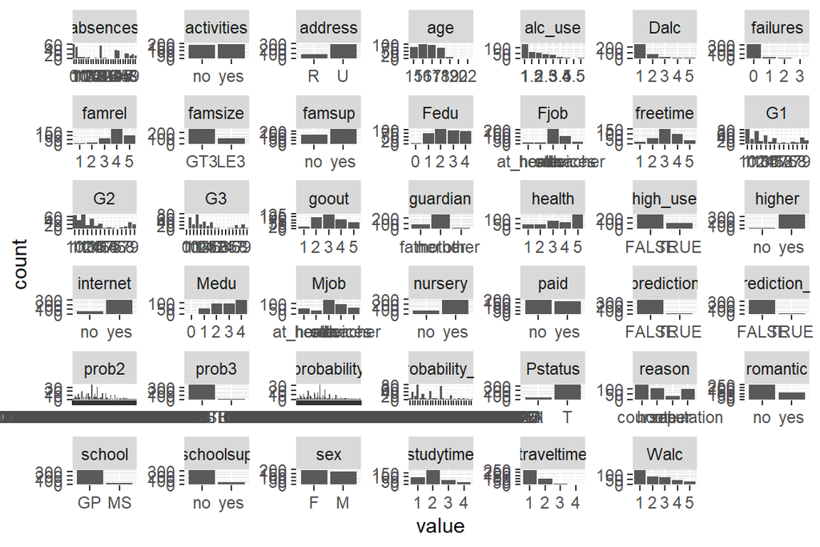

```r
# it may help to take a closer look by View() and browse the data
gather(alc) %>% View

# draw a bar plot of each variable
gather(alc) %>% ggplot(aes(value)) + facet_wrap("key", scales = "free") + geom_bar()
```

*Above is the plot of each variable in the data set and represent how each variable is distributed*

## About my 4 chosen variables

*I am choosing the following variable* **schoolsup** *- extra educational support(binary: yes or no)* **higher** *- wants to take higher education (binary: yes or no)* **famrel** *- quality of family relationships (numeric: from 1 - very bad to 5 - excellent)* **final grade** *numeric: from 0 to 20, output target*

*The variable ‘schoolsup’ will help me to understand the impact of high alcohol use on how much support the student need in their studies.* **My hypothesis** *is that with increased alcohol use, there will be increase the support needed*

*With the help of the variable ‘higher’, I want to study whether the willingness to pursue higher studies changes between those who consume more alcohol than others.* **My hypothesis** *is that there will be an effect but not so significant on desire to pursue higher education with increased alcohol consumption*

*the ‘famrel’ variable will help me understand the effect of high alcohol usage on the relationship with family.* **My hypothesis** *is that there will be a strain in relationship with family with high consumption*

*‘final grade’ variable with help me see if there is change in final grades of the student with higher usage as compared to lower usage* **My hypothesis** *is that the marks will be negatively effected with high consumption of alcohol*

#Exploring the chosen variables through visualization

#1.Exploring high_use with schoolsup i.e., extra support need from school

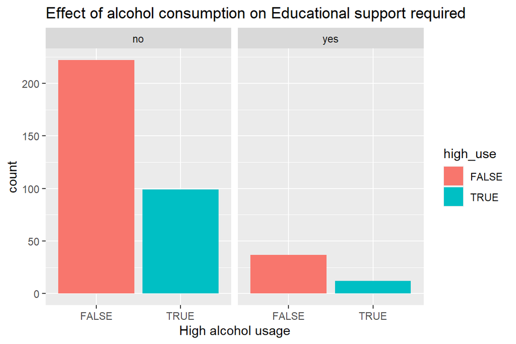

```r
# access the tidyverse libraries dplyr and ggplot2
library(dplyr); library(ggplot2)

g1 <- ggplot(alc, aes(x = high_use))

g1 + geom_bar() + facet_wrap("schoolsup") + ggtitle("Effect of alcohol consumption on Educational support required") + xlab("High alcohol usage") + aes(fill = high_use)
```

**Observation** *From the above visualization we can observe that, there are comparatively less students whose alcohol usage is high and requires extra educational support. Interestingly, students for those alcohol usage isn’t high, they seek more support from the school when compared to those with high usage.* *My hypothesis stands false for this which is very interesting for me*

#2. Exploring high_use with higher i.e. desire for higher eduation

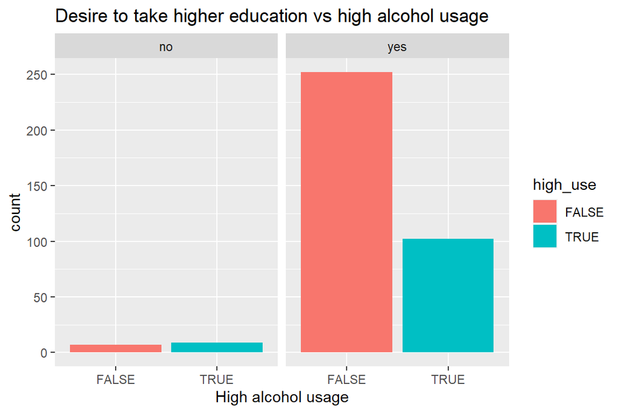

```r
g2 <- ggplot(alc, aes(x = high_use))

g2 + geom_bar() + facet_wrap("higher") + ggtitle("Desire to take higher education vs high alcohol usage") + xlab("High alcohol usage") + aes(fill = high_use)
```

**Observation** *The above variable stands true to my hypothesis that no matter how much is the consumption for alcohol, the desire for higher education doesn’t go away. Lets take a closer look below*

#Summarising to see results see more clearly

```r
alc %>% group_by(higher, high_use) %>% summarise(count = n())
```

```
## # A tibble: 4 × 3
## # Groups:   higher [2]
##   higher high_use count
##   <chr>  <lgl>    <int>
## 1 no     FALSE        7
## 2 no     TRUE         9
## 3 yes    FALSE      252
## 4 yes    TRUE       102
```

**Observation** *There are only 16 students that do not desire to pursue higher education out of which 9 were with high usage. This means that there is no significant relationship between alcohol usage and desire to study further, which seems logical to me as food choices can be temporary but the choice for further studies is a thought through decision for most people.*

#3. Exploring high_use and its effect on famrel i.e., family relationship

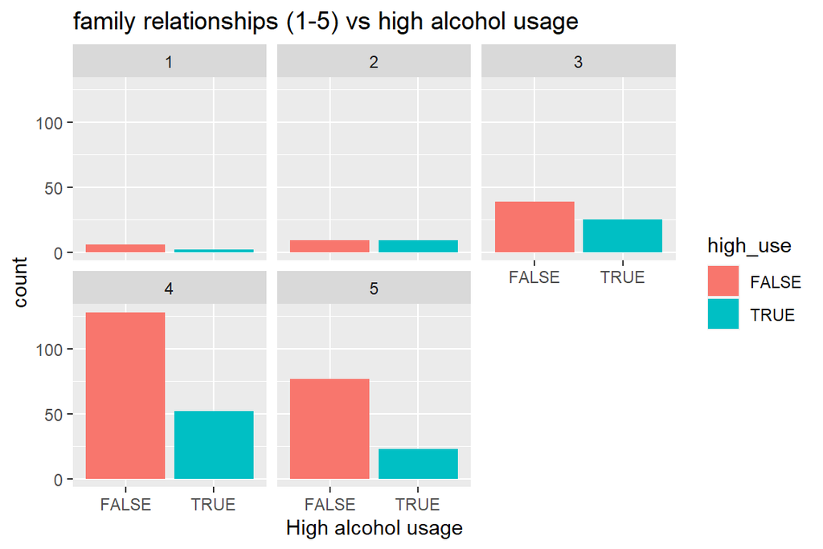

```r
g3 <- ggplot(alc, aes(x = high_use))

g3 + geom_bar() + facet_wrap("famrel") + ggtitle("family relationships (1-5) vs high alcohol usage") + xlab("High alcohol usage") + aes(fill = high_use)
```

**Observation** *Family relationship for most students have been on the positive side without any significant change with high or low usage of alcohol. Infact in the category of bad relationship, the proportion of those with low usage is higher but that is true as there are more number of students with low usage as compared to high usage in general.* *Therefore, my hypothesis of effect being negative stands false*

#4. Exploring high_use and its effect on G3 i,e., Final Grades of student

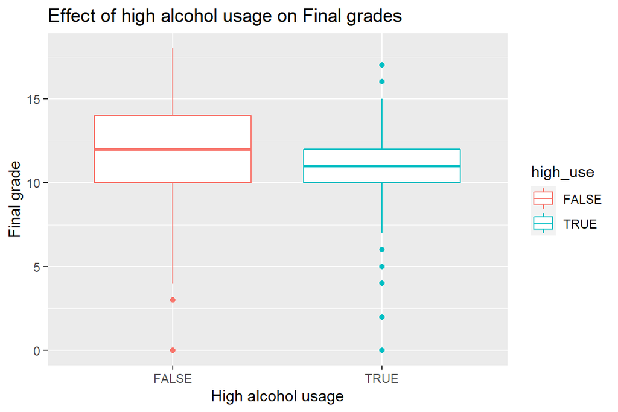

```r
g4 <- ggplot(alc, aes(x = high_use, y = G3))

g4 + geom_boxplot() + ggtitle("Effect of high alcohol usage on Final grades") + xlab("High alcohol usage") + ylab("Final grade")+ aes(col = high_use)
```

**Observation** *We can clearly visualize that the students with high consumption have comparatively lower grades than those with low consumption.* *The hypothesis for the variable stands true that high alcohol consumption has negatively effected the grades of students*

## Logistic Regression Model

**About Logistic regression model**

*Logistic regression is used to predict the class (or category) based on one or multiple predictor variables (x). It is used to model a binary outcome, that is a variable, which can have only two possible values*

*We will now use Logistic regression model to identify factors related to higher than average student alcohol consumption.*

```r
# find the model with glm()
m <- glm(high_use ~ schoolsup + higher + famrel + G3, data = alc, family = "binomial")

# print out a summary of the model
summary(m)
```

```
##
## Call:
## glm(formula = high_use ~ schoolsup + higher + famrel + G3, family = "binomial",
##     data = alc)
##
## Deviance Residuals:
##     Min       1Q   Median       3Q      Max
## -1.4957  -0.8206  -0.7292   1.3560   1.9346
##
## Coefficients:
##              Estimate Std. Error z value Pr(>|z|)
## (Intercept)   1.83332    0.74905   2.448   0.0144 *
## schoolsupyes -0.37002    0.35929  -1.030   0.3031
## higheryes    -0.78379    0.55077  -1.423   0.1547
## famrel       -0.27320    0.12418  -2.200   0.0278 *
## G3           -0.07269    0.03692  -1.969   0.0490 *
## ---
## Signif. codes:  0 '***' 0.001 '**' 0.01 '*' 0.05 '.' 0.1 ' ' 1
##
## (Dispersion parameter for binomial family taken to be 1)
##
##     Null deviance: 452.04  on 369  degrees of freedom
## Residual deviance: 437.36  on 365  degrees of freedom
## AIC: 447.36
##
## Number of Fisher Scoring iterations: 4
```

```r
# print out the coefficients of the model
coef(m)
```

```
##  (Intercept) schoolsupyes    higheryes       famrel           G3
##   1.83331647  -0.37001600  -0.78378621  -0.27320431  -0.07269305
```

*There we 4 Fisher scoring iterations before the process of fitting the model stopped and output the results.*

## From coefficients to odds ratios(OR)

```r
# find the model with glm()
m <- glm(high_use ~ schoolsup + higher + famrel + G3, data = alc, family = "binomial")

# compute odds ratios (OR)
OR <- coef(m) %>% exp

# compute confidence intervals (CI)
CI <- confint(m) %>% exp
# print out the odds ratios with their confidence intervals
cbind(OR, CI)
```

```
##                     OR     2.5 %     97.5 %
## (Intercept)  6.2545955 1.4672230 28.1361910
## schoolsupyes 0.6907233 0.3292951  1.3616633
## higheryes    0.4566737 0.1504271  1.3477672
## famrel       0.7609373 0.5955510  0.9708981
## G3           0.9298862 0.8644588  0.9995539
```

#Plot Visualisation by providing Confidence Intervals

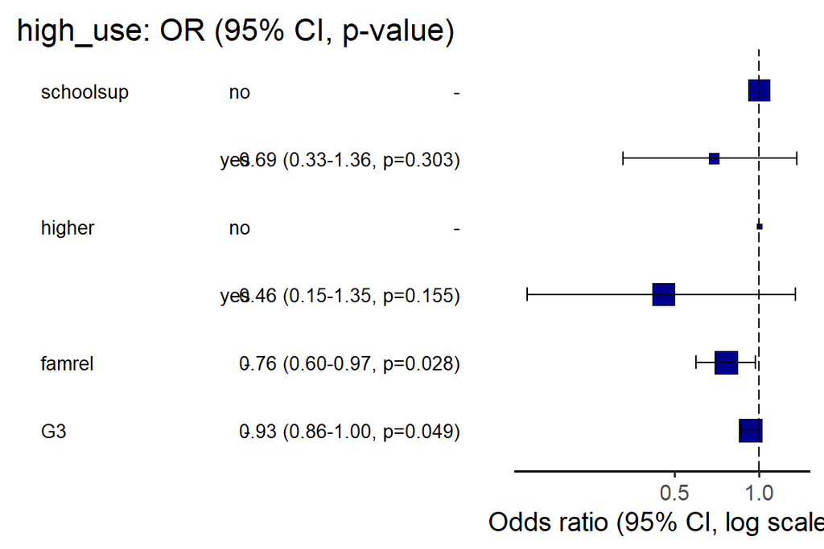

```r
library(finalfit)
dependent <- "high_use"
explanatory <- c("schoolsup", "higher", "famrel", "G3")
alc %>%
  or_plot(dependent, explanatory,
          breaks = c(0.5, 1, 2, 5),
          table_text_size = 3.5,
          title_text_size = 16)
```

## Explore the predictive power of the model with the significant variables

#Binary prediction (1)

```r
# fit the model
m <- glm(high_use ~ schoolsup + higher + famrel + G3, data = alc, family = "binomial")
m1 <- glm(high_use ~ famrel + G3, data = alc, family = "binomial")

# predict() the probability of high_use
probabilities <- predict(m, type = "response")
prob2 <- predict(m1, type = "response")

library(dplyr)

# add the predicted probabilities to 'alc'
alc <- mutate(alc, probability = probabilities)
alc <- mutate(alc, prob2 = prob2)

alc <- mutate(alc, prediction = probability > 0.5)

# use the probabilities to make a prediction of high_use
alc <- mutate(alc, prob3 = prob2 > 0.5)

# see the last ten original classes, predicted probabilities, and class predictions
select(alc, schoolsup, higher, famrel, G3, high_use, probability, prediction) %>% tail(10)
```

```
## # A tibble: 10 × 7
##    schoolsup higher famrel    G3 high_use probability prediction
##    <chr>     <chr>   <dbl> <dbl> <lgl>          <dbl> <lgl>
##  1 no        yes         4    13 FALSE          0.271 FALSE
##  2 no        yes         4     0 FALSE          0.489 FALSE
##  3 no        yes         5     2 TRUE           0.387 FALSE
##  4 no        yes         5    12 FALSE          0.233 FALSE
##  5 no        yes         4     8 FALSE          0.349 FALSE
##  6 no        yes         5     5 FALSE          0.336 FALSE
##  7 no        yes         4    12 FALSE          0.286 FALSE
##  8 no        yes         1     4 FALSE          0.619 TRUE
##  9 no        yes         2    13 TRUE           0.391 FALSE
## 10 no        yes         4    10 TRUE           0.316 FALSE
```

```r
# tabulate the target variable versus the predictions
table(high_use = alc$high_use, prediction = alc$prediction)
```

```
##         prediction
## high_use FALSE TRUE
##    FALSE   251    8
##    TRUE    103    8
```

**Observation** *The model has predicted False as 251/259* *The model has predicted True as 8/111* *The sensitivity of the model is 8 which is not so good and specificity is 251 which is much better*

*In the cross table, 8 times the prediction is heavy alcohol consumption when the variable gets a value corresponding to no heavy alcohol consumption. Similarly, 103 times the prediction is no high alcohol consumption when the variable gets a value corresponding to high alcohol consumption.*

```r
# rerunning some codes to avoid errors

m <- glm(high_use ~ schoolsup + higher + famrel + G3, data = alc, family = "binomial")
alc <- mutate(alc, probability = predict(m, type = "response"))
alc <- mutate(alc, prediction = probability > 0.5)
```

#Binary prediction (2)

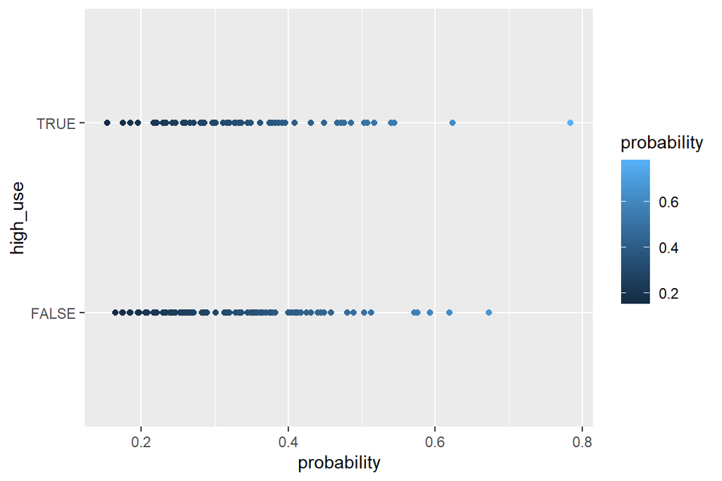

```r
# initialize a plot of 'high_use' versus 'probability' in 'alc'
g <- ggplot(alc, aes(x = probability, y = high_use))

# define the geom as points and draw the plot
g + geom_point() + aes(col = probability)
```

```r
# tabulate the target variable versus the predictions
table(high_use = alc$high_use, prediction = alc$prediction) %>% prop.table() %>% addmargins()
```

```
##         prediction
## high_use      FALSE       TRUE        Sum
##    FALSE 0.67837838 0.02162162 0.70000000
##    TRUE  0.27837838 0.02162162 0.30000000
##    Sum   0.95675676 0.04324324 1.00000000
```

**Observation** *The table above shows that, according to the forecast, there are about 95 percent of all people who do not drink a lot of alcohol. There are approximately 70 percent of all persons who do not drink much alcohol. Note again that the forecast differs from the values of the variable.*